# Exercice 6

# Tache 1: Reflection

Selon les lectures proposées on constate que la question : comment représenter de la meilleure façon l’incertitude, n’a pas encore été répondu. Il y a plusieurs façons proposées de représenter l’incertitude, mais aucune manière ne permet au public en général de comprendre réellement ce que l’incertitude représente. Même chez les spécialistes, l’incertitude est parfois traitée avec peu de rigueur comme dans le cas des cônes des tornades où l’incertitude est représentée d’une manière qui confond le public. On pense que le cône représente la grosseur que la tornade va atteindre et non l’ensemble des trajectoires possible. Il y a aussi le cas de la fameuse aiguille sensée représenté l’incertitude entourant les prédictions électorales. Les gens ont pensé que les résultats variait beaucoup, car l’aiguille bougeait beaucoup alors qu’en réalité les résultats ont été clair assez vite.

# Tâche 2: Visualiser l’incertitude avec gapminder

Pour cet exercice, vous allez revoir les données de Hans Rosling sur la santé et la richesse. Installez le package **gapminder** si vous ne l’avez pas déjà fait. Installez également les packages **ggridges** et **gghalves**.

```r
library(tidyverse)  # For ggplot, dplyr, and friends
library(gapminder)  # For health/wealth data
library(ggridges)   # For ridge plots
library(gghalves)   # For half geoms
```

## Histogrammes

Faites un histogramme du PIB *enregistré* par habitant pour 1997 uniquement, sur les cinq continents.

```r
# Créer un jeu de données filtré
data_gdp <- gapminder::gapminder
data_1997 <- data_gdp %>%
  filter(year == 1997)
```

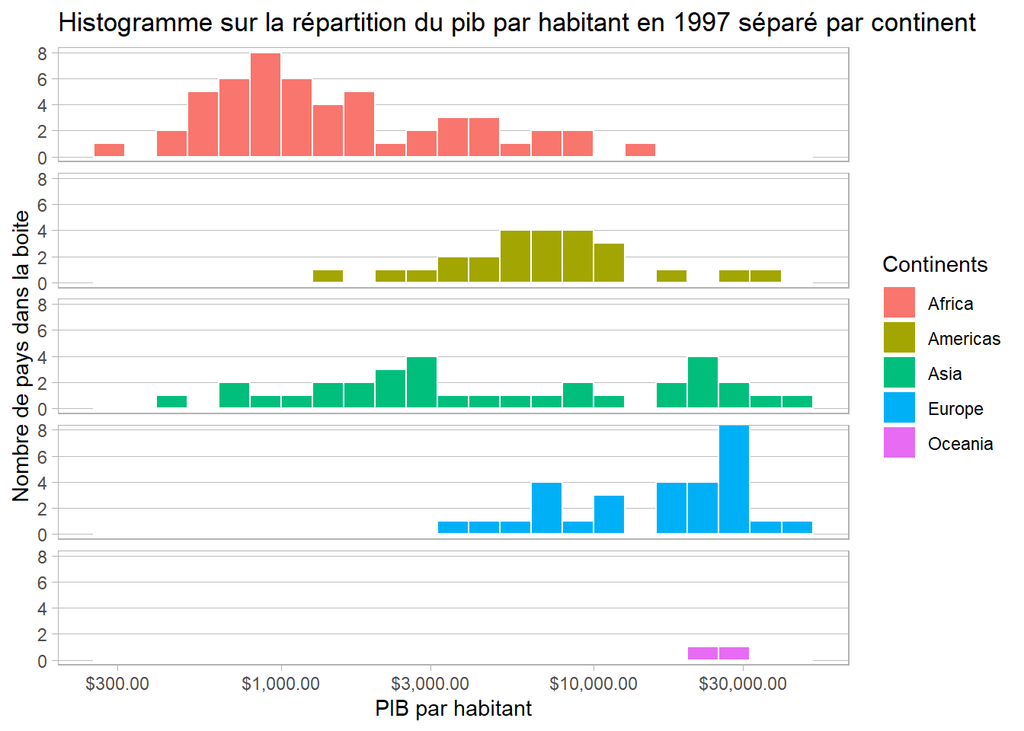

```r
# Ajoutez un histogramme ici. Vous voudrez probablement remplir et facetter.
# Vous devrez également ajouter scale_x_log10()
library(scales)
ggplot(data_1997, mapping = aes(gdpPercap, fill = continent)) +
  geom_histogram(color = "white", binwidth = 0.1, boundary = 1000) +
  scale_x_log10(labels = label_dollar()) +
  coord_cartesian(ylim = c(0, 8)) +
  facet_grid(row = vars(continent)) +
  labs(title = "Histogramme sur la répartition du pib par habitant en 1997 séparé par continent",
       y = "Nombre de pays dans la boite",
       x = "PIB par habitant",
       fill = "Continents") +
  theme_light() +
  theme(strip.background = element_blank(),
        strip.text = element_blank(),
        panel.grid = element_blank(),
        panel.grid.major.y = element_line(color = "gray"))
```

## Densités

Faites un tracé de crête de l’espérance de vie au fil du temps, de 1952 à 2007. Vous devrez utiliser les données complètes de gapminder, et non les données de 1997 uniquement.

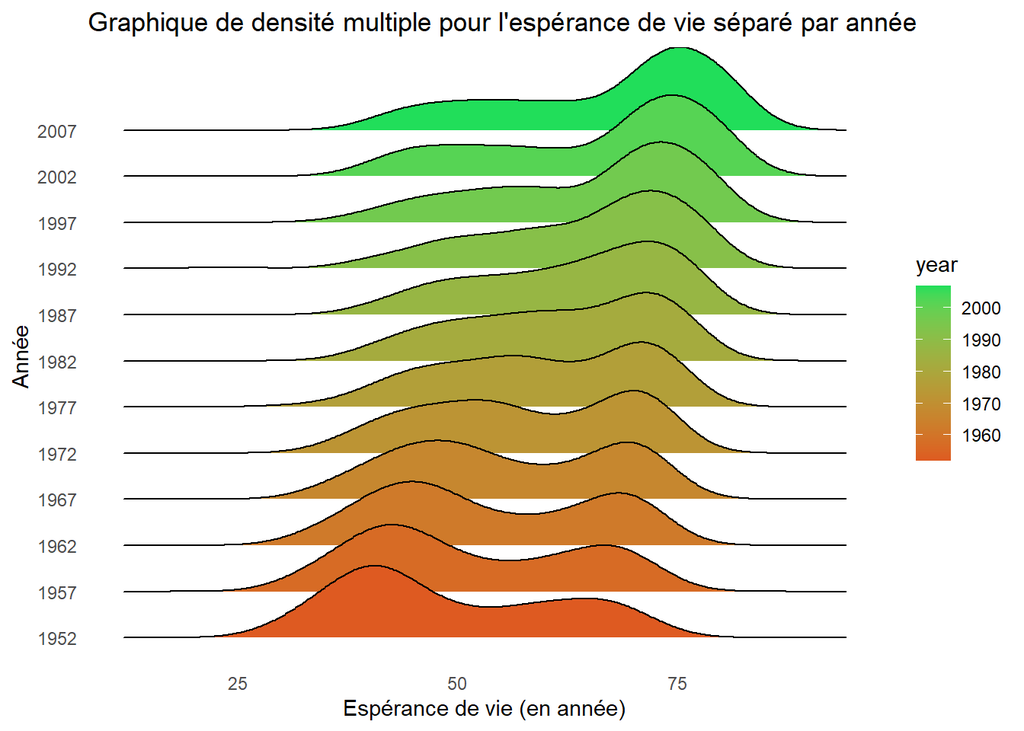

```r
# Add a ridge plot here
library(ggridges)
ggplot(data_gdp, mapping = aes(lifeExp,
                               as.factor(year),
                               fill = year)) +
  geom_density_ridges() +
  scale_fill_gradient(low = "#DE5A21", high = "#21DE5A") +
  labs(title = "Graphique de densité multiple pour l'espérance de vie séparé par année",
       x = "Espérance de vie (en année)",
       y = "Année") +
  theme_minimal() +
  theme(panel.grid = element_blank())
```

## Boîtes, violons et amis

Créez un jeu de données filtré qui sélectionne uniquement les données de 2007 *et* supprime l’Océanie. Montrez la distribution du PIB *enregistré* par habitant sur les *quatre* continents en utilisant une combinaison de diagrammes en boîte et/ou de diagrammes en violon et/ou de diagrammes en bande, soit superposés les uns sur les autres, soit en utilisant leurs homologues `geom_half_*()` de **gghalves**.

```r
# Create a filtered dataset
data_2007 <- data_gdp %>%
  filter(year == 2007 & continent != "Oceania")
```

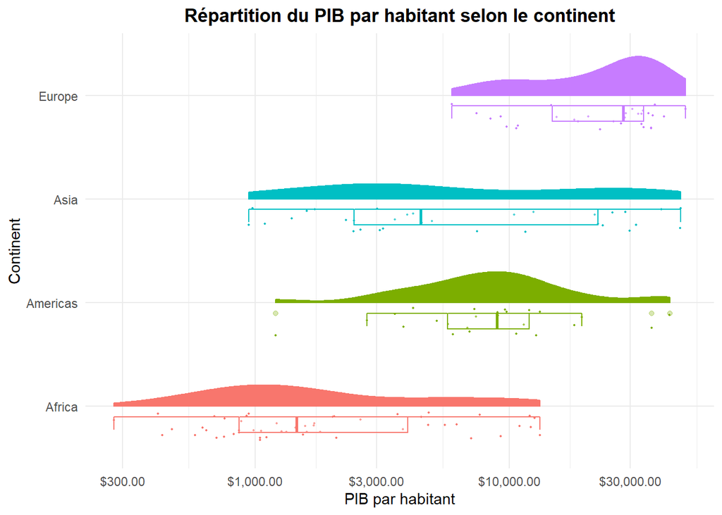

```r
# Add a plot here. You'll want to use either scale_x_log10() or scale_y_log10(),
# depending on which direction your boxplots/violin plots/etc. go
library(gghalves)
ggplot(data_2007, mapping = aes(continent,
                                gdpPercap,
                                color = continent)) +
  geom_half_point(side = "l",
                  size = 0.3) +
  geom_half_boxplot(side = "l",
                    width = 0.5,
                    alpha = 0.3,
                    nudge = 0.1) +
  geom_half_violin(aes(fill = continent),
                   side = "r") +
  scale_y_log10(labels = label_dollar()) +
  coord_flip() +
  labs(title = "Répartition du PIB par habitant selon le continent",
       y = "PIB par habitant",
       x = "Continent") +
  guides(fill = "none",
         color = "none") +
  theme_minimal() +
  theme(plot.title = element_text(hjust = 0.5,
                                  face = "bold"))
```

# Référence

Nicosia, A. (2022). Incertitude [PowerPoint slides]. Moodle. https://moodle.uqac.ca/pluginfile.php/883741/mod_page/content/2/Incertitude.pdf